# R Notebook

# Exploration work for wk 4 of “Building Data Products” on Cloudera

## Objective

I want to build a Shiny app that displays word clouds from presidential addresses

## Part 1: Exploration and feasibility

### Getting some data

A google serach revealed that the Guntenberg project offered a the full text of inaugural addresses from G. Washington to G.W. Bush. I decided to use this text. The text can be found [here](http://www.gutenberg.org/cache/epub/925/pg925.txt). After looking for tokenizing the text by president and years, I foudn out that the author of the package had kindly do the work… so I will use this instead.

```r
library(quanteda)
inaug <- data_corpus_inaugural
```

### What would a data science project be without some wrangling, right ?

```r
library(tm)
library(magrittr)
library(SnowballC)
#let's make a corpus, a collection of our inuagural texts
inaugCorp <- Corpus(VectorSource(inaug$documents$texts))
#Let's clean up a bit
inaugCorp <- inaugCorp %>%
                tm_map(content_transformer(tolower)) %>%
                tm_map(removePunctuation) %>%
                tm_map(removeNumbers) %>%
                tm_map(removeWords,stopwords("SMART"))
#Some stemming (reduce world to their stem)
#inaugCorp <- inaugCorp %>%
#        tm_map(stemDocument) #Stemming is provided by the snowballC library
```

Now that we have tidied up our texts, we need to create a word could. To do this, we need to calculate the frequency of each terms in each document. The lm library come with a handy function called `TermDocumentMatrix` that will create the frequency matrix of document terms. Let’s try this.

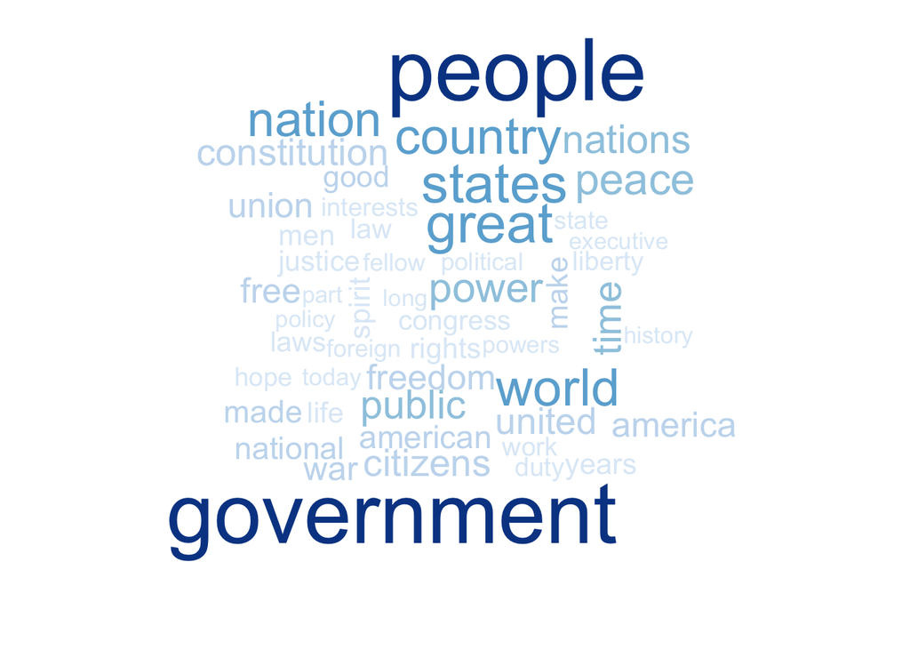

```r
        library(wordcloud)
        # That's for all inaugural addresses, if you want the TDM for a specific one, just get a specicif one from the corpus
        inaugTDM <- TermDocumentMatrix(inaugCorp,control =list(minWordLength = 1))
        #make it a Matrix  so it is somewhat humanely readable and sort...
        inaugTermsMat <- as.matrix(inaugTDM)
        #sort so it is easier for the world cloud
        inaugTermsMat <- sort(rowSums(inaugTermsMat),decreasing=TRUE)
        wordcloud(names(inaugTermsMat),inaugTermsMat,max.words = 50,colors=brewer.pal(8,"Blues"))
```

### Part 1: Conclusion

We sourced the data we were looking for and we were able to create a word cloud from all inaugural addresses since George Washington. Pretty cool !

## Prepping for Shiny

We will give the option for users to pick all presidents, a specific inaugural address, if multiple presidents then offer the year or a combination of all their inaugurations.

```r
#let's get a list of presidents:
prez <- paste0(inaug$documents$Year,"-",inaug$documents$President)
#Locate President Obama 2009 inaugural Address
prezInd <- match("2009-Obama",prez)
prezCorp <- inaugCorp[prezInd]
```

So the input will be a drop down with the year and president name, we could get fancy and brea it down by century of example. For now, we will keep it simple. Additionally users can choose the number of words in the tag cloud. I aslo decided not the stem the text.

## Drawing a cloud

We will draw a cloud for president Obama 2009 inaugural address.

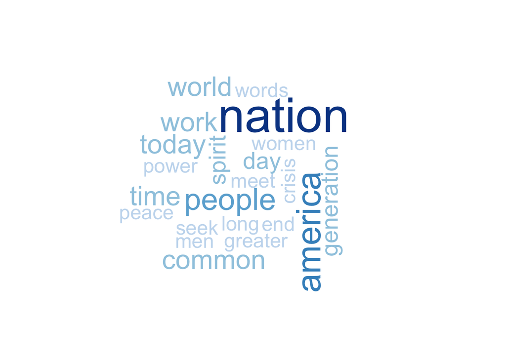

```r
        # That's the basis of our function for the shiny app
        inaugBama <- as.matrix(TermDocumentMatrix(prezCorp,control =list(minWordLength = 1)))
        inaugBama <- sort(rowSums(inaugBama),decreasing =TRUE)
        wordcloud(names(inaugBama),inaugBama,max.words = 30,min.freq = 4, colors=brewer.pal(8,"Blues"))
```